## Maps and Projections

```r
library(sf)
library(tidyverse)
library(ggthemes)
library(ggspatial)
library(units)
library(nngeo)
library(RColorBrewer)
```

### Download data

```r
neighborhoods <- st_read("http://bostonopendata-boston.opendata.arcgis.com/datasets/3525b0ee6e6b427f9aab5d0a1d0a1a28_0.kml?outSR=%7B%22latestWkid%22%3A2249%2C%22wkid%22%3A102686%7D",
                         quiet = TRUE)

schools <- st_read("http://bostonopendata-boston.opendata.arcgis.com/datasets/1d9509a8b2fd485d9ad471ba2fdb1f90_0.geojson?outSR=%7B%22latestWkid]%22%3A2249%2C%22wkid%22%3A102686%7D",
                 quiet = TRUE)
```

### Plot the neighborhoods and the schools

Each geom_sf is one layer. If you plot a region on top of the points, you won’t be able to see these points. Make sure to place regions and polygons at the beginning of your code.

legend.position can be “right”, “left”, “top” and “bottom”, but you can also specifiy its position by the x,y coordinates of the plot itself.

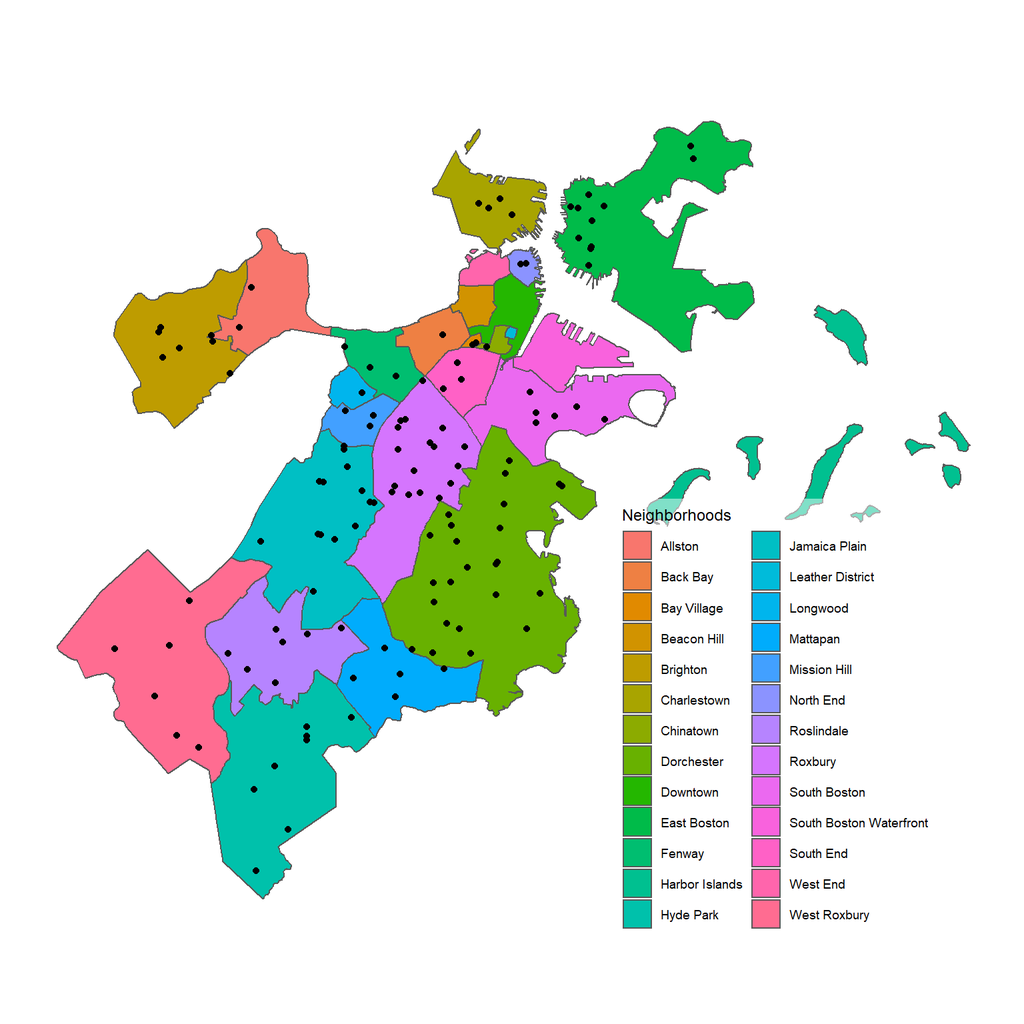

```r
ggplot(neighborhoods) +
  geom_sf(aes(fill=Name)) +
  geom_sf(data = schools) +
  theme_map() +
  theme(legend.position = c(0.6, 0),
        legend.background = element_rect(fill=alpha("white", 0.5))) +
  guides(fill=guide_legend(title="Neighborhoods"))
```

### Count the number of schools in each neighborhood

st_covers creates a list of lists: LargeList = [list1, list2, …listn] where each element within the LargeList contains points that are located within a given region.

```r
test <- st_covers(neighborhoods, schools)
lengths(test)
```

```
##  [1]  7 14  3  1  2  0  1  2 17  4  1 11  4  0  0  0  3  6  7  8  5 25  0  6  4
## [26]  0
```

```r
neighborhoods <- neighborhoods %>%
  mutate(schools = lengths(st_covers(neighborhoods, schools)))
```

You can specify your own color ranges with scale_fill_gradientn

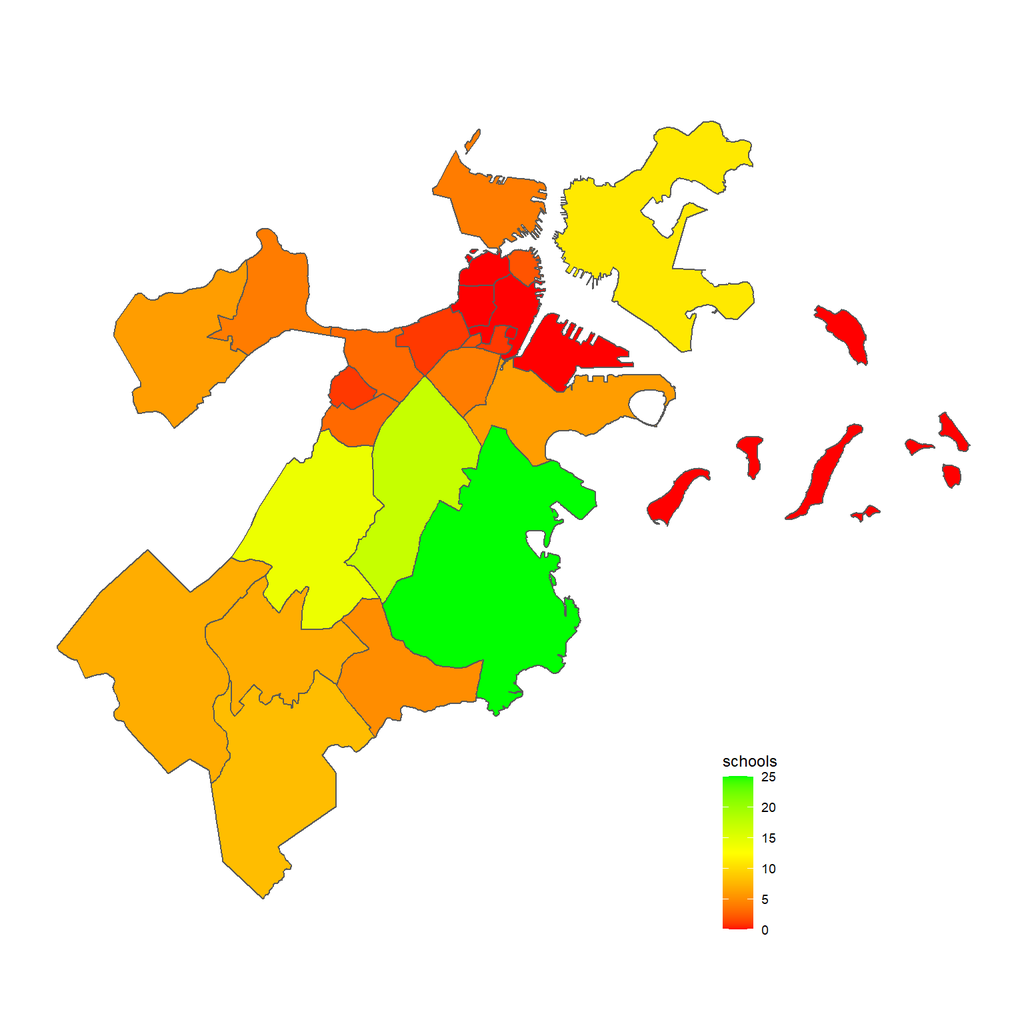

```r
ggplot(neighborhoods) +
  geom_sf(aes(fill=schools)) +
  theme_map() +
  scale_fill_gradientn(colors = c("red", "yellow", "green"))+
  theme(legend.position = c(0.7, 0))
```

What if some values are missing?

```r
#this code replaces the element in the first row and column "schools" with NA.
neighborhoods[1,"schools"] <-NA
```

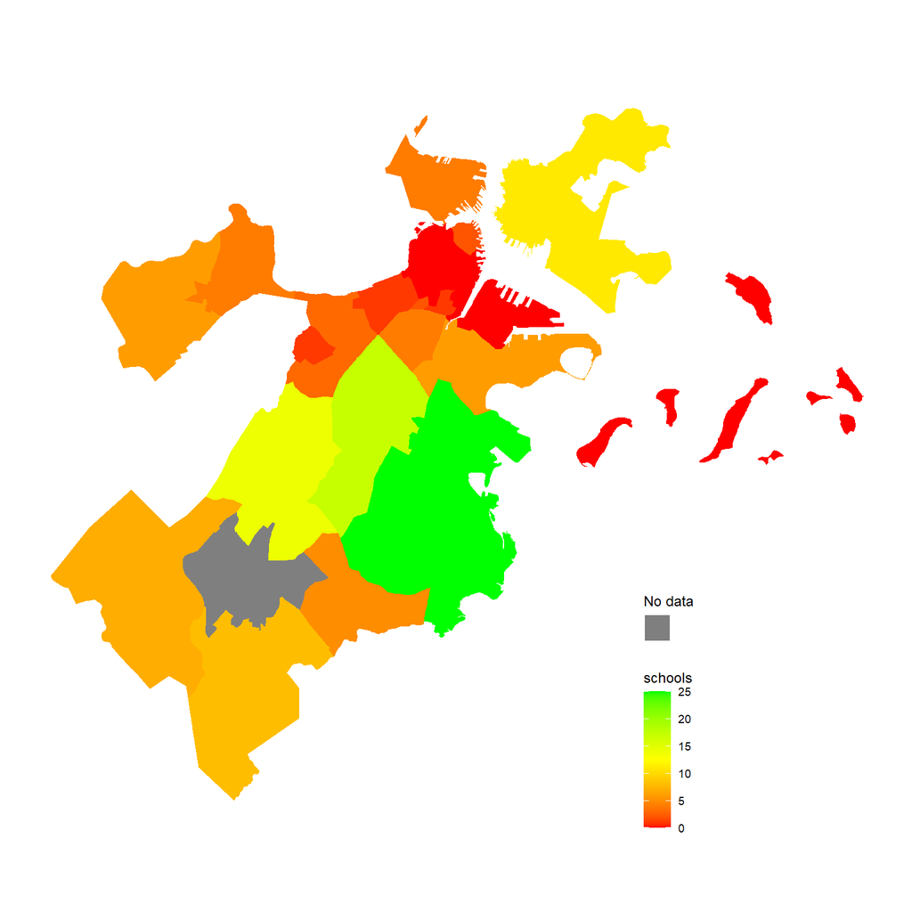

```r
# R will display the missing value as a grey color by default.
# To add grey to the legend, add color="", and the last two rows of the code.


ggplot(neighborhoods) +
  geom_sf(aes(fill=schools, color="")) +
  theme_map() +
  scale_fill_gradientn(colors = c("red", "yellow", "green"), na.value = "grey50")+
  theme(legend.position = c(0.7, 0)) +
  scale_color_manual(values = NA, name = "No data")+
  guides(color=guide_legend("No data", override.aes=c(fill="grey50")))
```

## Projections

What is the difference between using transformed and original spatial data?

```r
water_not_transformed <- st_read("http://bostonopendata-boston.opendata.arcgis.com/datasets/2b3c0fa13b1c468eb702a3645fcc6bcb_5.kml",
                 quiet = TRUE)

parking_not_transformed <- st_read("http://bostonopendata-boston.opendata.arcgis.com/datasets/962da9bb739f440ba33e746661921244_9.kml",
                   quiet = TRUE)

trees_not_transformed <- st_read("http://bostonopendata-boston.opendata.arcgis.com/datasets/ce863d38db284efe83555caf8a832e2a_1.kml",
                 quiet = TRUE)

nhoods_not_transformed <- st_read("http://bostonopendata-boston.opendata.arcgis.com/datasets/3525b0ee6e6b427f9aab5d0a1d0a1a28_0.kml",                   quiet = TRUE)
```

```r
MA_state_plane <- "+proj=lcc +lat_1=41.71666666666667 +lat_2=42.68333333333333 +lat_0=41 +lon_0=-71.5 +x_0=200000 +y_0=750000 +ellps=GRS80 +units=m +no_defs"

nhoods <- nhoods_not_transformed %>%
  st_transform(MA_state_plane)

water <- water_not_transformed %>%
  st_transform(MA_state_plane)

parking <- parking_not_transformed %>%
  st_transform(MA_state_plane)

trees <- trees_not_transformed %>%
  st_transform(MA_state_plane)
```

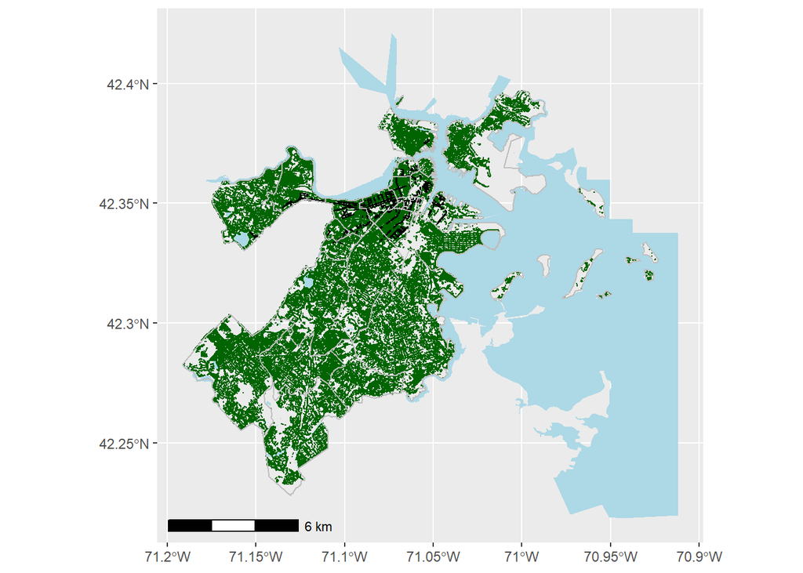

```r
ggplot(water_not_transformed) +
  geom_sf(fill = "lightblue", color = NA) +
  geom_sf(data = trees, color = "darkgreen", size = 0.01) +
  geom_sf(data = parking_not_transformed, size = 0.01) +
  geom_sf(data= nhoods, fill = NA, color = "gray") +
  annotation_scale()
```

Plot 2: With transformation

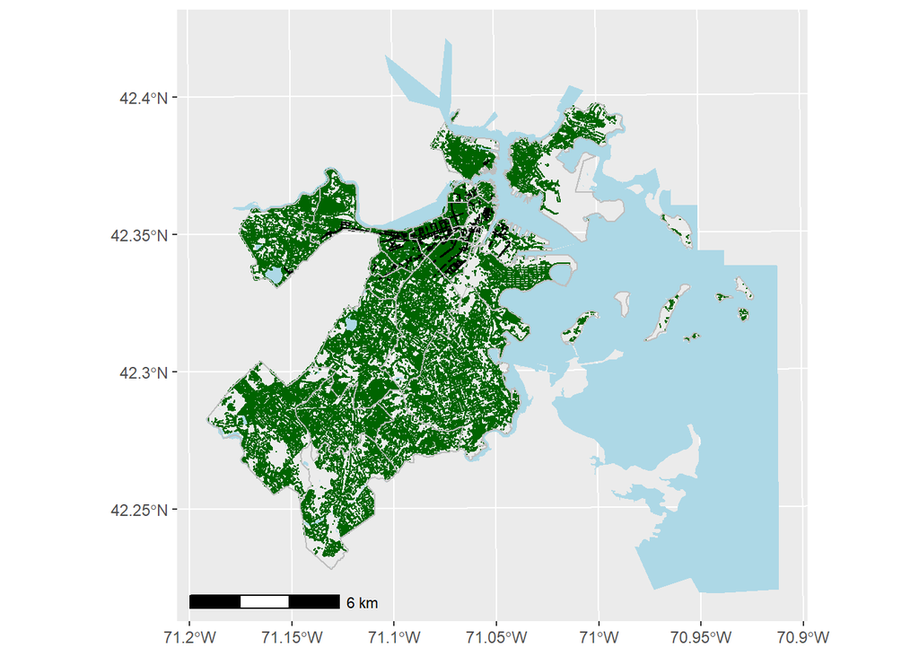

```r
ggplot(water) +
  geom_sf(fill = "lightblue", color = NA) +
  geom_sf(data = trees, color = "darkgreen", size = 0.01) +
  geom_sf(data = parking, size = 0.01) +
  geom_sf(data= nhoods, fill = NA, color = "gray") +
  annotation_scale()
```

These two plots are equal! However, if we try to work with distances, the difference will be evident.

Plot A: Buffers with transformation

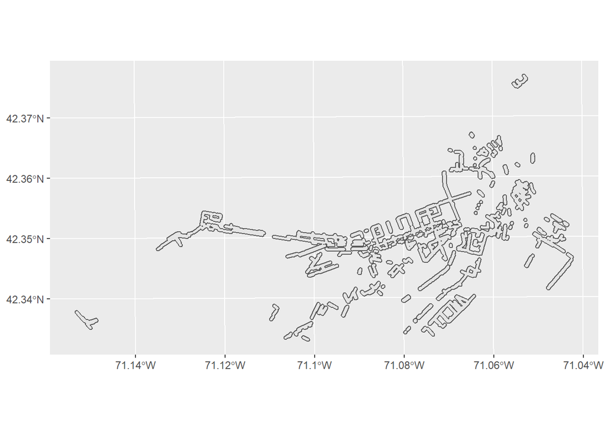

```r
#  buffer function from Carole's written example, with transformation.

parking_buffer <- st_buffer(parking, dist = 30) %>%
  st_union()

ggplot(parking_buffer) +
  geom_sf()
```

Plot B: Buffers with no transformation

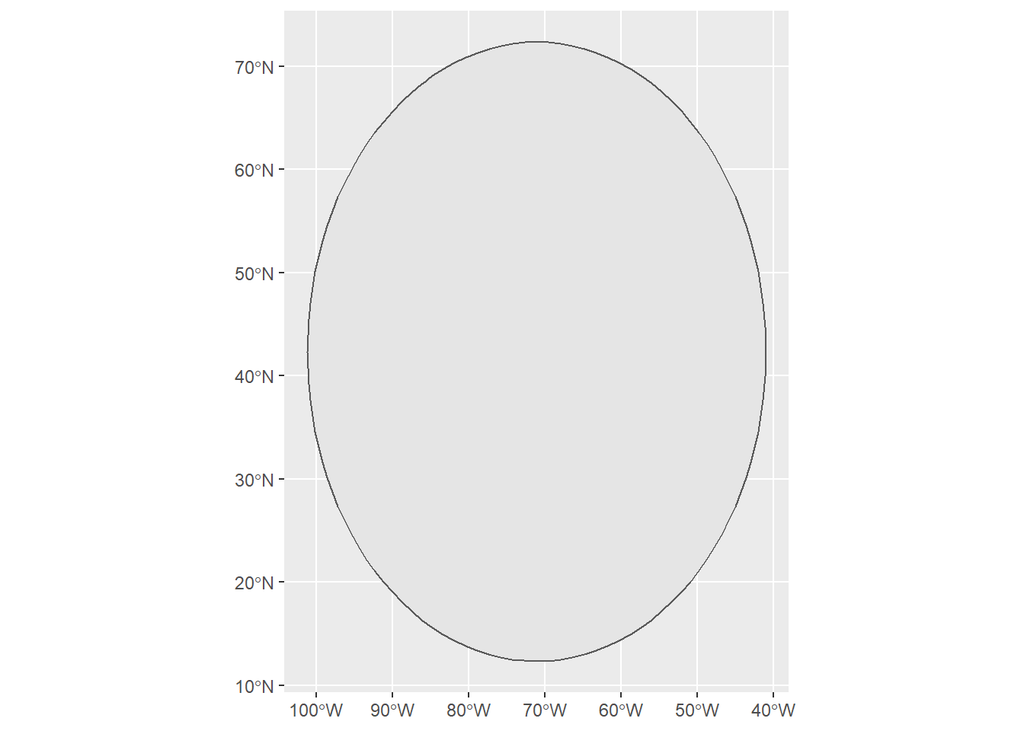

```r
#  buffer function from Carole's written example, without transformation.dist = 30 is 30 degrees, not 30m.

parking_buffer <- st_buffer(parking_not_transformed, dist = 30) %>%
  st_union()

ggplot(parking_buffer) +
  geom_sf()
```

Plot C: Buffers with no transformation, but with degrees converted to meters.

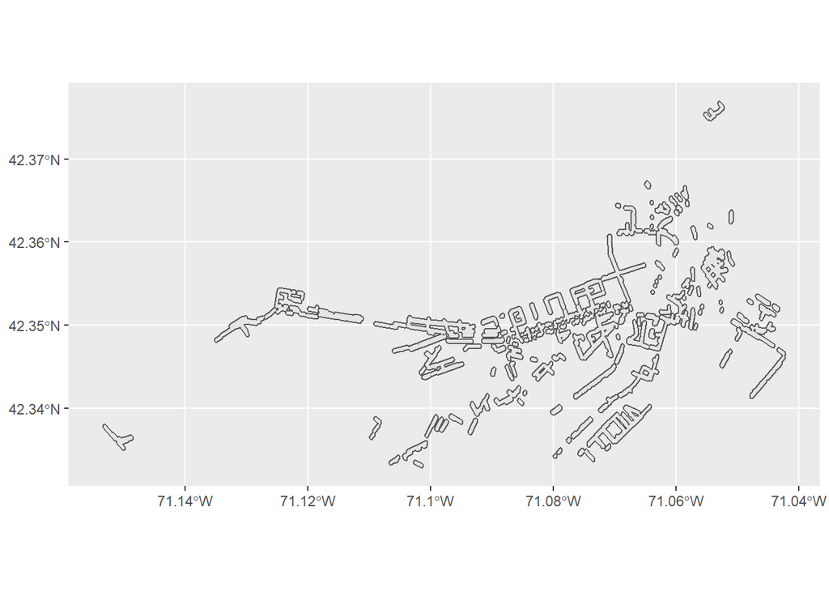

```r
parking_buffer <- st_buffer(parking_not_transformed, dist = 0.0002702703) %>%
  st_union()

ggplot(parking_buffer) +
  geom_sf()
```